# Kruzlic Homework 5

HW5 First Attempt

Bryn Kruzlic  
2022-04-24

# *Overview of Final Project*

> The dataset I am using for my final project is a set taken from ‘Kaggle’, containing all of the songs and lyrics from Taylor Swift’s discography up until 2017. Due to the wide range of albums containing 20+ songs each, I will be comparing the lyrics of the first album ‘Taylor Swift’ and the most recent in the data set ‘Reputation’.Later in my research, I will introduce the middle albums in order to further emphasize the trends being shown throughout the album and the themes in each one individually.

```r
library(readr)
library(tidyverse)
library(tidyselect)
library(dplyr)
library(ggplot2)
library(tidytext)
library(stringr)
```

## Locate the File

```r
Swift_lyrics <- read_csv("C:/Users/Bryn Kruzlic/OneDrive/Desktop/DACSS601/taylor_swift_lyrics.csv")
View(Swift_lyrics)
```

### Preview of the Data

```r
head(Swift_lyrics)
```

```
# A tibble: 6 x 7
  artist       album        track_title track_n lyric       line  year
  <chr>        <chr>        <chr>         <dbl> <chr>      <dbl> <dbl>
1 Taylor Swift Taylor Swift Tim McGraw        1 "He said ~     1  2006
2 Taylor Swift Taylor Swift Tim McGraw        1 "Put thos~     2  2006
3 Taylor Swift Taylor Swift Tim McGraw        1 "I said, ~     3  2006
4 Taylor Swift Taylor Swift Tim McGraw        1 "Just a b~     4  2006
5 Taylor Swift Taylor Swift Tim McGraw        1 "That had~     5  2006
6 Taylor Swift Taylor Swift Tim McGraw        1 "On backr~     6  2006
```

## Tidy Data

Based on the size of the dataset, there are many factors that do not need to be included in our research. For example, articles in the lyrics such as “I”, “a”, “we”, “the”, etc. *do not* need to be included, as those words would clearly be the most popular out of any song that could be analyzed.

```r
library(stringr)
library(dplyr)
library(tokenizers)

df <- data.frame(Swift_lyrics)

tidy_lyric <- Swift_lyrics %>%
  unnest_tokens(word, lyric)

word_count <- tidy_lyric %>%
  group_by(track_title) %>%
  summarise(num_words = n()) %>%
  arrange(desc(num_words))
```

# Visualizations

*At this stage, I was able to use the ‘token’ feature to separate the ‘lyric’ column into individual words, in order to find trends within the lyrics. Since the data set contains multiple albums with 10+ tracks each, my research will filter out the middle albums to show the progression between the first studio album and the last one[^1]*

## Word Count Distribution

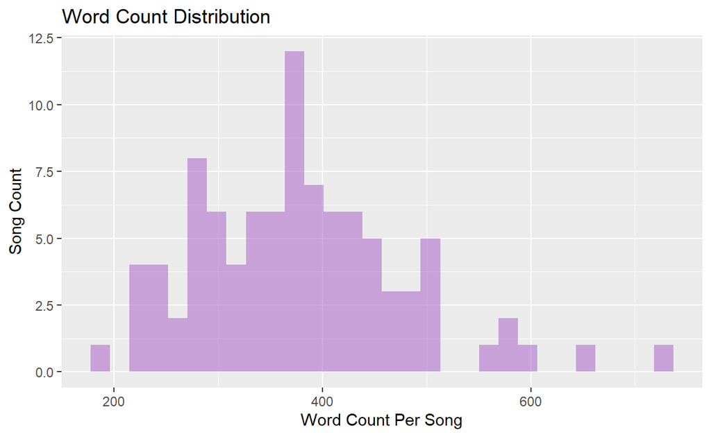

```r
word_count %>%
  ggplot() +
  geom_histogram(aes(x = num_words), fill = "#a458c4", alpha =.5) +
  ylab("Song Count") +
  xlab("Word Count Per Song") +
  ggtitle("Word Count Distribution")
```

*I am visualizing the word count per song, which is a way to map out the amount of words per song in order to me to dissect the lyrics and word types within the songs later on in the project. We can conclude at this point that the word count per songs tend to be within the 300-500 range. With this information, we can see how many potential words we are working with and how often the words within these songs are repeated, and how the words may change.*

## Frequently Used Words

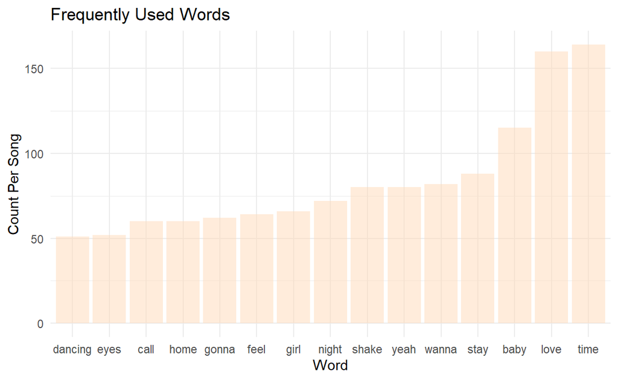

```r
tidy_tslyric <- tidy_lyric %>%
  anti_join(stop_words) %>%
  filter(nchar(word) > 3)

tidy_tslyric %>%
  count(word, sort = TRUE) %>%
  top_n(15) %>%
  ungroup() %>%
  mutate(word = reorder(word,n)) %>%
  ggplot() +
  geom_col(aes(word, n), fill = "#FFDAB8", alpha = .5) +
  xlab("Word") +
  ylab("Count Per Song") +
  ggtitle("Frequently Used Words") +
  theme_minimal()
```

*Here, I am visualizing the frequency of certain words within the discography and which ones appear the most. The small chunk of code at the top is being used to filter out articles such as “I”, “a”, “the”, etc. which are unimportant words in this research. We could reasonably conclude with no tidying at all that these articles and short words would appear the most frequently. I am interested in every word besides them.*